# Survey_analysis

MDP

13/10/2021

# Introduction

We will analyze the data coming from the ExpMed GSS about experiences of students in the program. It contains information about the characteristics of the student, their funding (received and applied for), the courses they have taken and opinions about different aspects of the program and the graduate student experience in our program.

# Demographic data

In this section we will explore the global characteristics of respondents in our ExpMed cohort.

- We had a response rate of **41% (82/197)** based on the registered Experimental Medicine students for Spring 2021
- Among responders, **74.4%** answered all the questions

A majority of the responders are domestic students in the MSc **(34.1)** or PhD program **(32.9%)**

| Progress | n | freq |
| --- | --- | --- |
| Fully complete | 61 | 74.39 |
| Partially complete | 21 | 25.61 |

| Program | Student type | n | % |
| --- | --- | --- | --- |
| MSc | Domestic | 28 | 34.15 |
| MSc | International | 5 | 6.10 |
| PhD | Domestic | 27 | 32.93 |
| PhD | International | 14 | 17.07 |

### Year in the program

Most of the MSc responders are in the first 2 years of the degree (as expected) and PhD respondents are mostly in their second to fourth year of the program. Thus, early PhD students are probably not represented in the sample.

Most international students are in year 2 or beyond. Probably, the pandemic has hindered the arrival of international students.

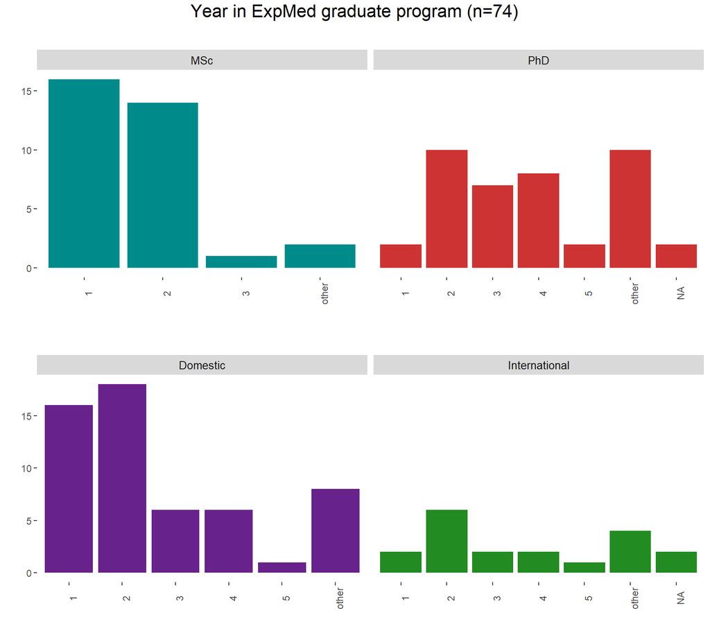

### Program start date

In this plot, we see the date of start in the X axis and the count of students in the Y-axis. Most of the MSc responders started in or after 2019. In contrast, start dates of PhD students are more evenly distributed.

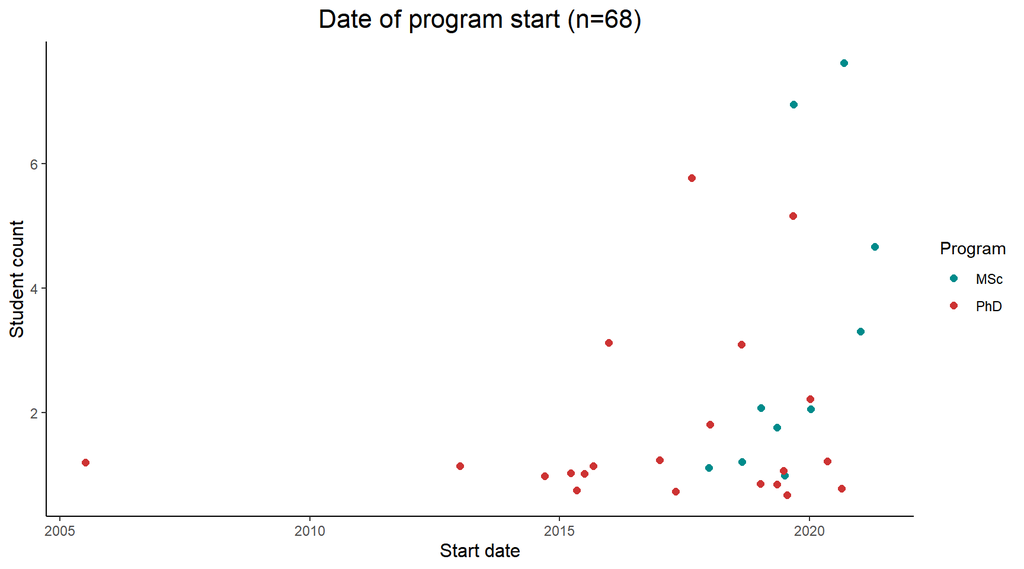

# Program feedback

The following questions report student satisfaction with the program and will be summarized by graduate program and international status.

### How reasonable or unreasonable is the tuition cost at this university?

In general, both MSc and Phd students found the tuition fees to be between somewhat reasonable, somewhat unreasonable and neither reasonable or unreasonable.

Domestic students showed a tendency to find the tuition somewhat reasonable as shown in the graph (45.4%).

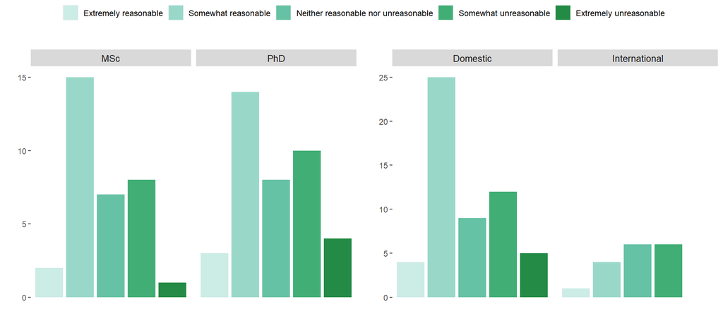

### Overall, how satisfied or dissatisfied are you with the ExMed program?

The most common responses of satisfaction with the program were in the categories of Somewhat satisfied and Neither satisfied nor disatisfied. This distribution did not change according to domestic status or type of program

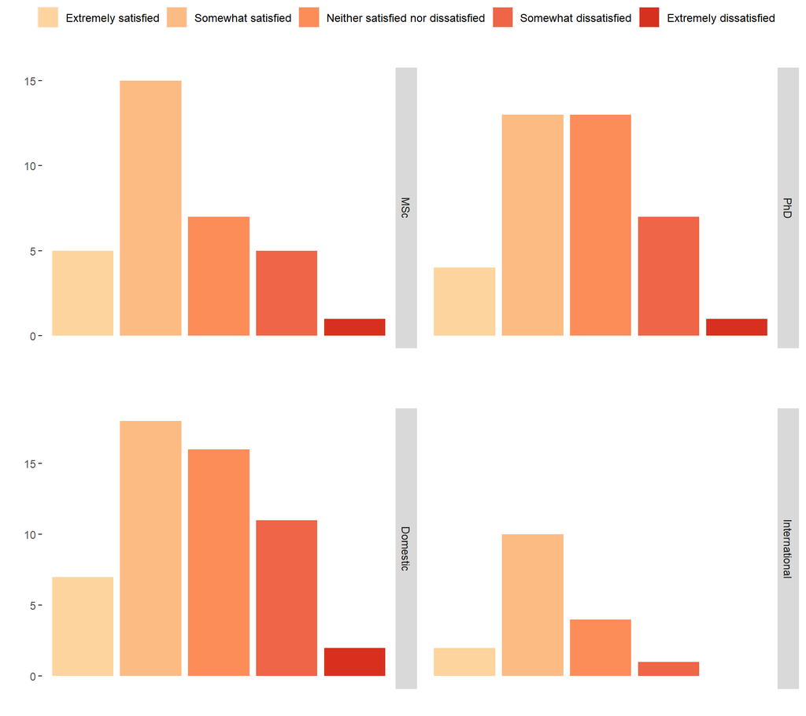

### How likely are you to recommend this program to students considering graduate school options?

In the question about how likely, from 1 to 10, were you to recommend the program to someone else. The score of answers from PhD students was lower (median=6) compared to those from the MSc program (median=7). These differences are non-significative in a nonparametric test (p=0.71). The likelihood of recommending the program is similar between international and domestic students

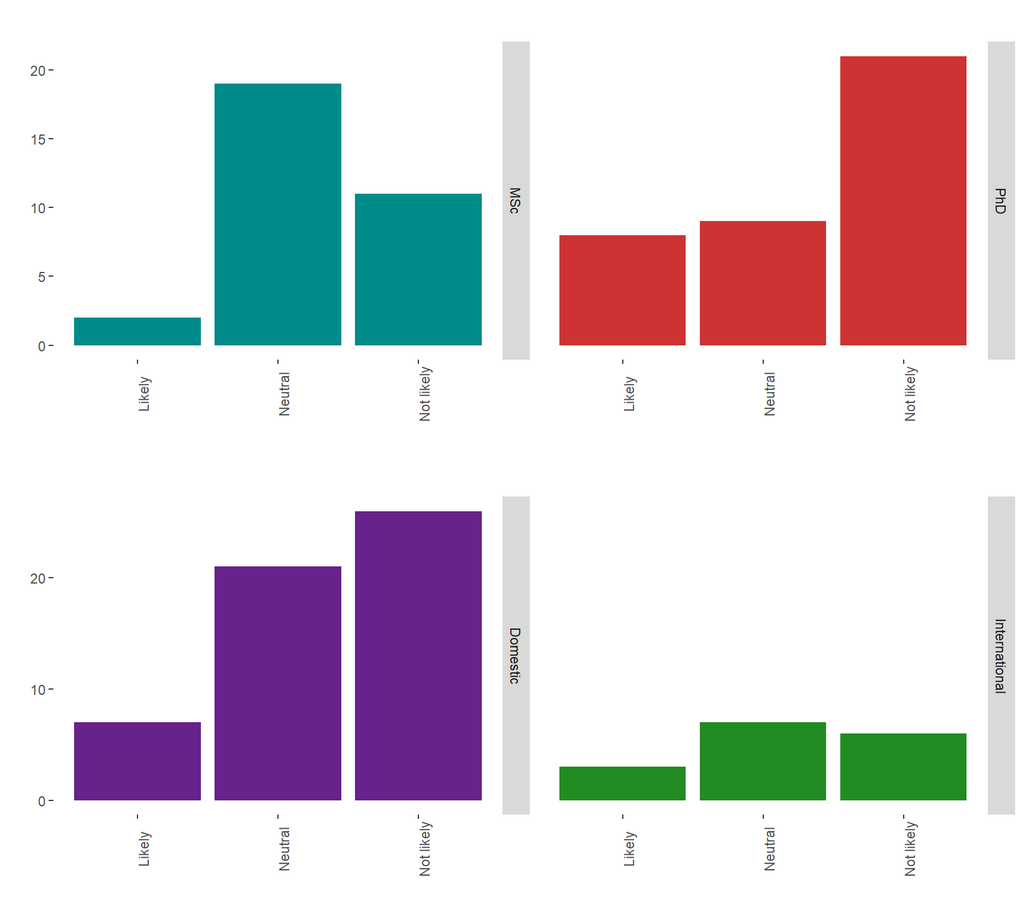

### Attend orientation and easiness of finding information

| Did you attend an ExMed orientation? | n | % |
| --- | --- | --- |
| No | 23 | 28.05 |
| Yes | 42 | 51.22 |
| NA | 17 | 20.73 |

In general, students answered that finding information about the program was somewhat easy. However, 12 (14.6%) of responders manifested that this process was somewhat difficult.

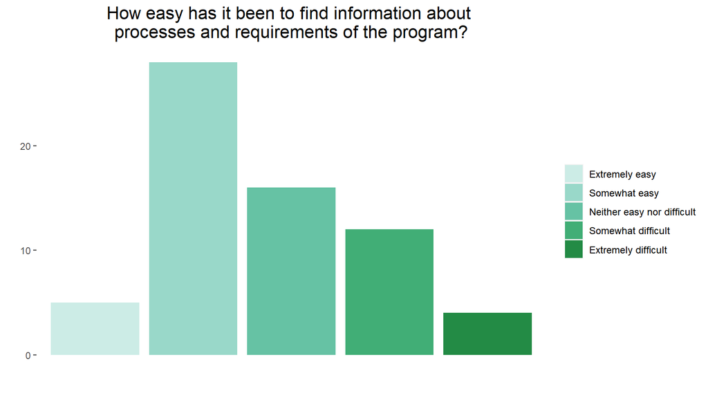

### Courses taken and courses feedback

Most of the students took coursed from the faculty of medicine, particularly the mandatory courses (MEDI 501, MEDI 502 & thesis courses). Only ~9% of the answers are about courses not listed. Maybe there is an opportunity for students to diversify their curriculum according to their interests.

| Course taken to meet requirements | n | % |
| --- | --- | --- |
| MEDI 501 | 38 | 22.09 |
| MEDI 502 | 47 | 27.33 |
| MEDI 503 | 19 | 11.05 |
| non MEDI course | 15 | 8.72 |
| other in MEDI | 53 | 30.81 |

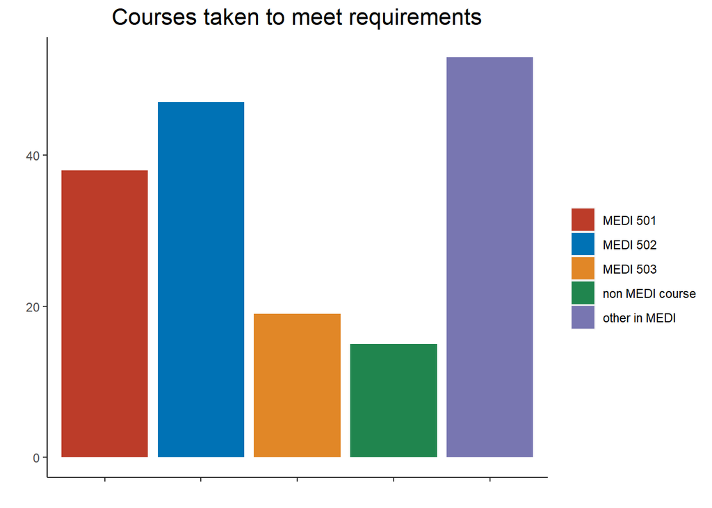

Respondents were mostly able to register in the desired courses **(64.6%)**. We could assume that there are enough seats in the MEDI courses as these were the most popular ones.

Not a lot of students registered non MEDI courses (n=14)

| Able to register in desired courses? | n | % |
| --- | --- | --- |
| Yes | 42 | 51.22 |
| No | 23 | 28.05 |
| NA | 17 | 20.73 |

| Experience registering courses outside of MEDI? | n |
| --- | --- |
| It was difficult | 5 |
| It was straightforward | 9 |

As we have seen in previous questions, answers gravitate between *neutral* and *somewhat satisfied* opinions. Satisfaction with the courses taken is high overall.

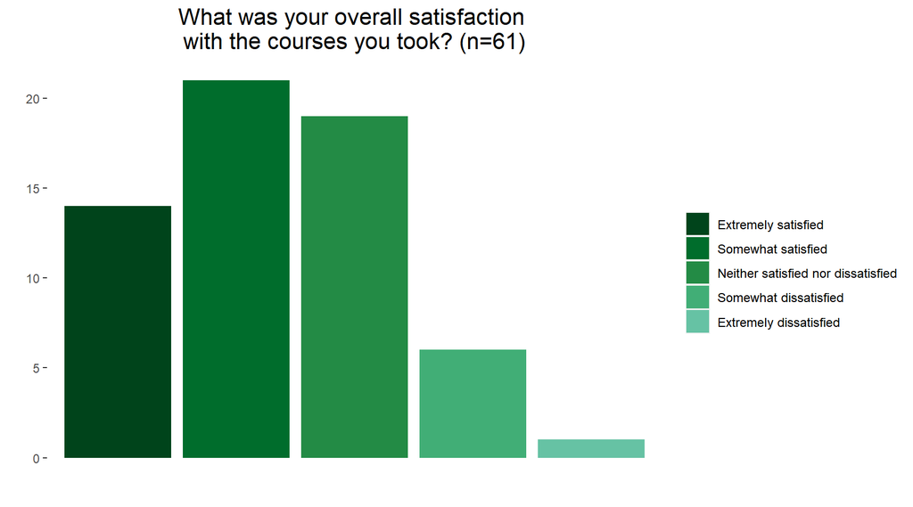

In general, students desire more elective courses from the faculty of Medicine. It could be interesting to follow-up with an initiative about what kind of courses. Maybe voting for broad categories (qualitative research, bioinformatics, public health, health economics, etc.)

| Do you feel that there should be more MEDI electives? | n | % |
| --- | --- | --- |
| Yes | 47 | 57.32 |
| No | 15 | 18.29 |
| NA | 20 | 24.39 |

### We are interested in hearing about your relationship with your supervisor

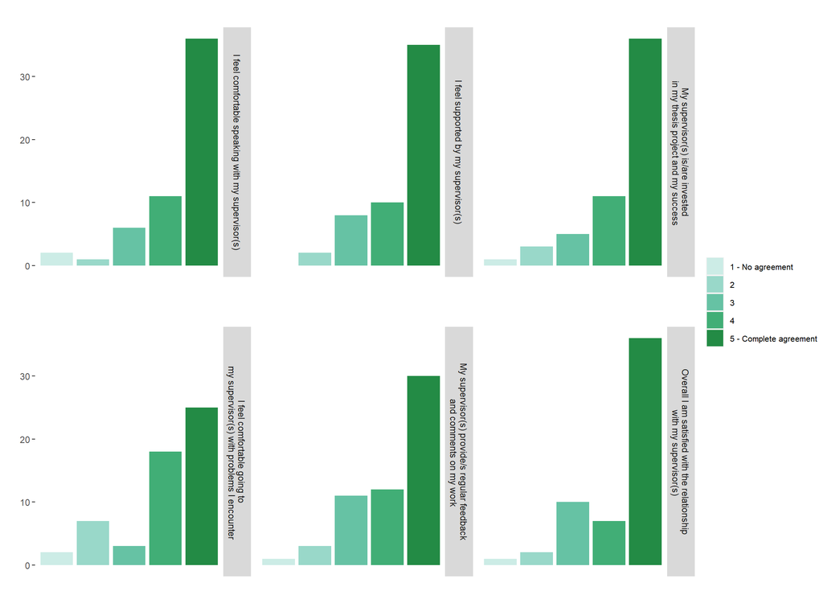

In this question, students show that they have a good relationship with their supervisors overall. They feel supported by them, comfortable enough to bring up difficult questions and feel that they have their best interests in mind.

# Funding

The following questions contain information about the funding received by students Unfortunately, most of the answers are open ended and need to be re-codified somehow or summarized in any other way.

### What average range of funding (CAD$) have you been receiving considering external funds combined?

[figure not shown]

The most frequent category selected for average funding receives is 20k-30k/year (36 43.9%), a similar number of participants responded >30k/year (11, 13.4%) and 18k-20k/year (10, 12.2%). Less than 5% reported receiving less than 18k/year.

This overall distribution held when we separated the answers according to type of program and also by domestic/international status. However, PhD students do report receiving funding over 30k/year more frequently.

### How often do you worry about funding/financial support for your studies and living?

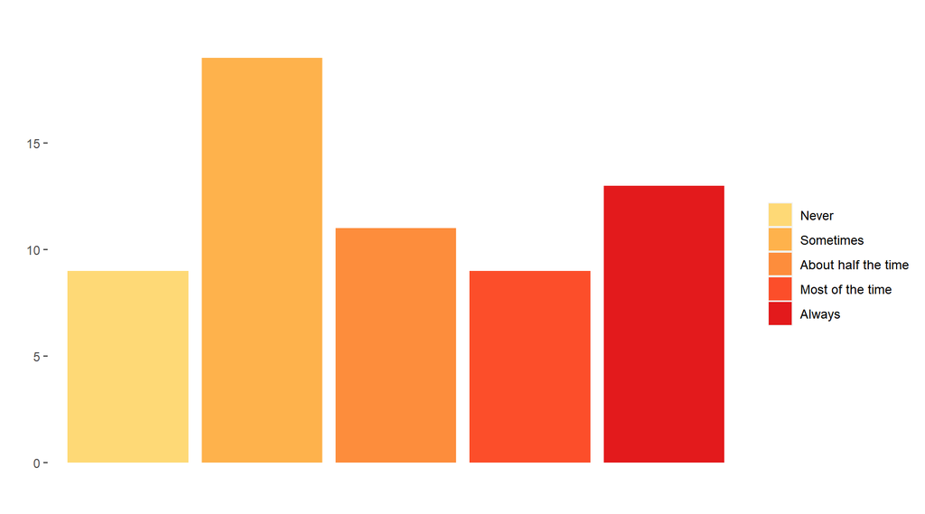

### Q53: To which funding opportunities have you applied to?

The most common funding schemes that students applied for are supervisor funding, faculty of medicine graduate awards and CGS (M/D) scholarships.

[output not shown]

These same funding opportunities were the ones more commonly awarded according to student answers.

# Impact of COVID-19 and wellbeing

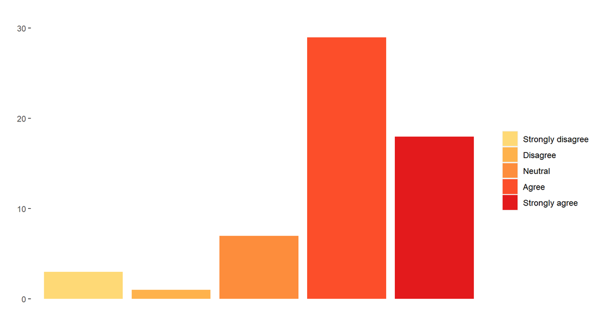

We asked several questions about the impact of the pandemic on several aspects of the training, responders scored between **1: No agreement** and **5: Complete agreement**

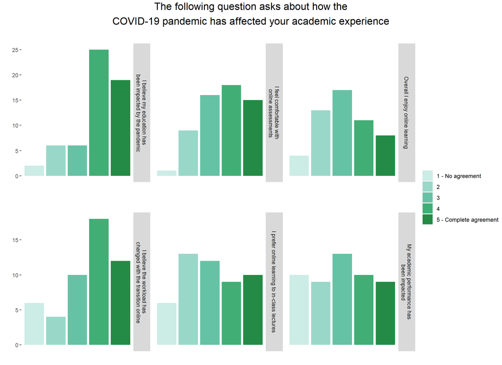

#### The following question asks about well-being, mental-health and academic resources available at UBC

| UBC service | Known by | % recognition |
| --- | --- | --- |
| UBC Student Health Services | 47 | 57.32 |
| UBC Counselling | 45 | 54.88 |
| Library Research Commons | 35 | 42.68 |
| Graduate + Postdoctoral Studies workshops | 35 | 42.68 |
| Wellness Centre: Online | 32 | 39.02 |
| SASC (Sexual Assault Support Centre) | 23 | 28.05 |
| Centre for Accessibility | 20 | 24.39 |
| Centre for Writing and Scholarly Communication | 19 | 23.17 |
| Centre for Student Involvement and Careers (e.g., career advising appointments) | 19 | 23.17 |
| AMS Peer Support | 18 | 21.95 |
| Faculty of Medicine: Office of Respectful Environments, Equity, Diversity, and Inclusion | 17 | 20.73 |

- The resources most well-known by *ExpMed* students are UBC counselling, UBC health services, Library research commons and the G+PS workshops.
- Resources for sexual violence or sexual assault are widely unknown according to the survey.
- Also, the less known service is the mistreatment office of the faculty of medicine.

Students also provided their level of satisfaction for the services that they have used. Here, we show the results for the 4 resources most commonly used.

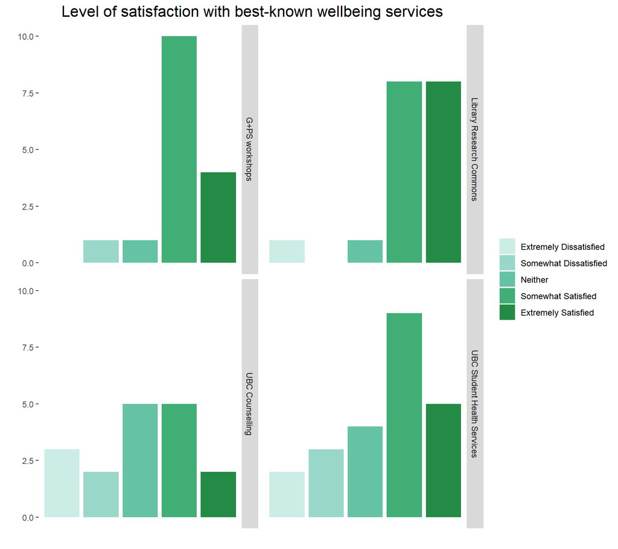

The most used resources are the UBC student health services (n=23), the Library research commons (n=18), UBC counselling (n=17) and G+PS workshops (n=16). Among them, the histograms show that the users are mostly satisfied for all but UBC counselling. There may be some increased demand due to the pandemic, but it may be interesting to explore why?

### We are interested in hearing about how you are doing/feeling in the program.

In this question, students ranked how much they agreed with every statement with **1: no agreement** and **5:complete agreement**

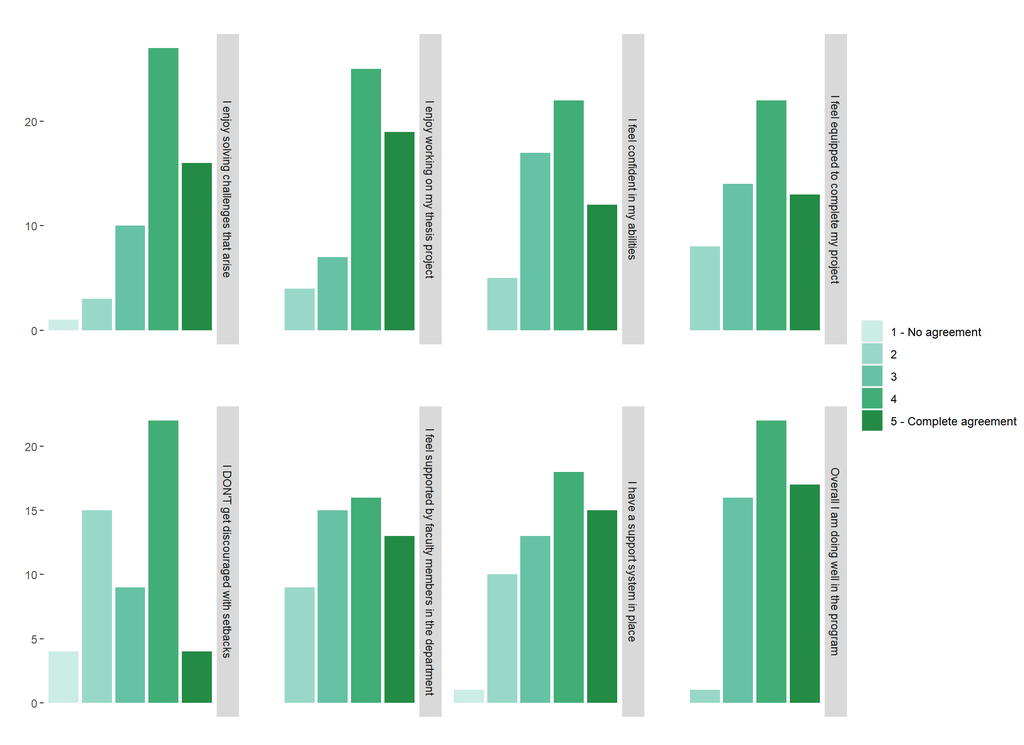

Overall, responders feel confident to approach setbacks and feel capable of completing the program successfully. Where we see less grouping around positive answers is in feeling supported by faculty members and not feeling discouraged by setbacks.

# Bullying and harrassment

The disclosure of bullying and harrassment was low, worth to explore as this was one of the resources that were highly unknown by the student sample. A significant portion **(7, 8.54%)** of all respondents have evidenced one of these episodes by **a faculty member**.

The percentage of responders that have experienced bullying **by someone other than a faculty member is less than 5%.**

| Have you ever experienced bullying/harassment? | n faculty member | % faculty member | n non-faculty member | % non-faculty member |
| --- | --- | --- | --- | --- |
| no | 50 | 60.98 | 53 | 64.63 |
| yes | 7 | 8.54 | 4 | 4.88 |
| NA | 25 | 30.49 | 25 | 30.49 |

In the cases were **someone experienced bullying (n=17)** only 5 reported the incident to an authority figure. Furthermore, as we see in the barplot, the resolution of the cases was not satisfactory at least from the point of view of the implicated students.

| Did you notify someone in a leadership position? | n | % |
| --- | --- | --- |
| no | 12 | 14.63 |
| yes | 5 | 6.10 |
| NA | 65 | 79.27 |

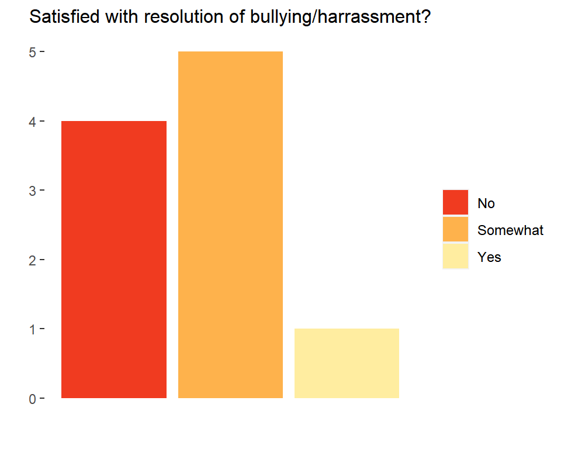